# Testing Rapsodo Hitting

Jacob Hallowell

# Setup

```r
# clean up workspace environment
rm(list = ls())

# all packages used for the assignment
library(mosaic)
library(tidyverse)
```

Now we want to load in our sheet of Hayden Stork’s rapsodo session stats.

```r
stork_stat <- read.csv('stork_sheet.csv', header = TRUE)
```

Now we can throw all of this data into different types of graphs.

## Spin

The first thing we want to look at is spin on Stork’s batted balls.

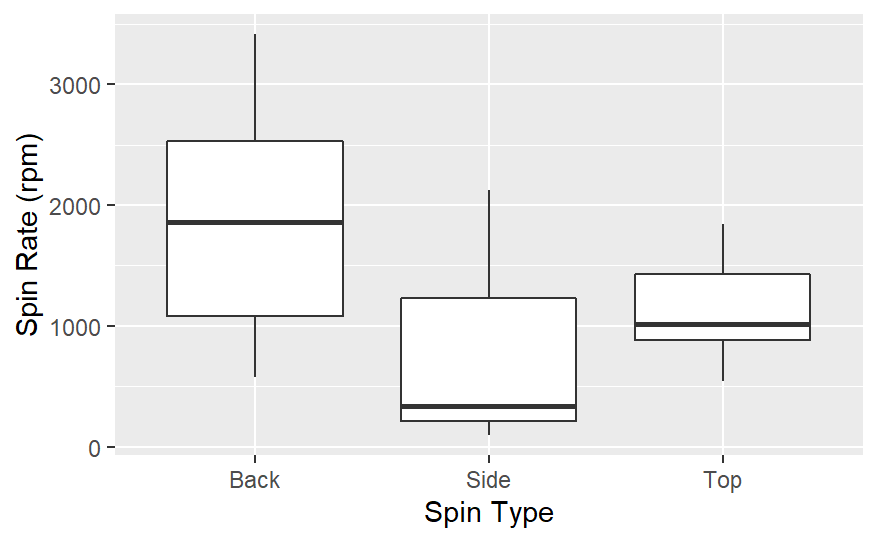

```r
stork_stat %>%
  ggplot(aes(x = Spin.type , y = Spin)) +
  geom_boxplot() +
  xlab("Spin Type") +
  ylab("Spin Rate (rpm)")
```

After looking at this graph we see that there were three tpes of spin (topspin, backspin, sidespin). The high spin rates were usually back spin, which makes sense because flyballs use backspin to somewhat “defy” gravity. This then makes the ball carry further.

To better understand spin, we want to look at the count of all the spins in the session.

```r
stork_stat %>%
  group_by(Spin.type) %>%
  count(Spin.type)
```

| Spin.type | n |
| --- | --- |
| Back | 22 |
| Side | 3 |
| Top | 10 |

So we can see that while Stork registered 35 hits, most of which were back spin. This would probably mean that there were a lot of fly balls.

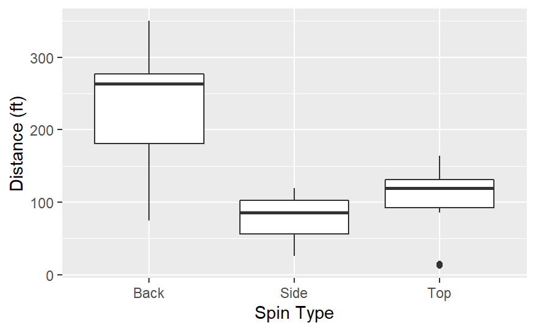

```r
stork_stat %>%
  ggplot(aes(x = Spin.type , y = Distance)) +
  geom_boxplot() +
  xlab("Spin Type") +
  ylab("Distance (ft)")
```

## Distance

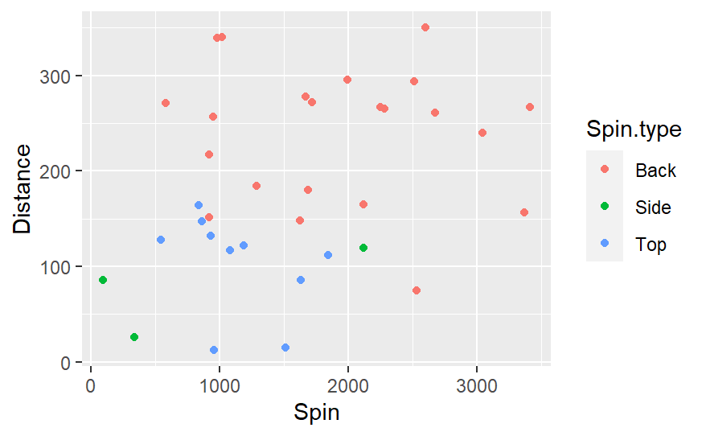

```r
stork_stat %>%
  ggplot(aes(x = Spin, y = Distance, color = Spin.type))+
  geom_point()
```

The plot above shows spin and distance.

## LA and EV

We want to look at some plots comparing the two.

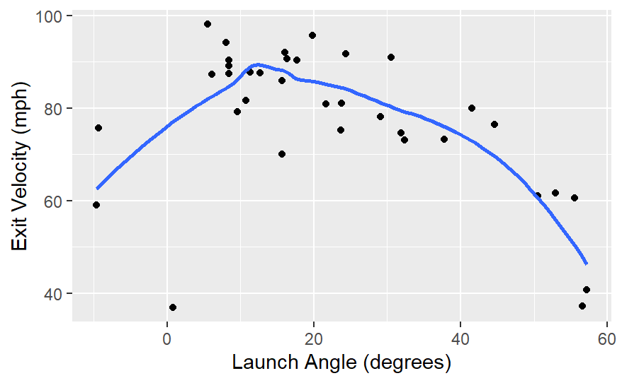

```r
stork_stat %>%
  ggplot(aes(x = L..Angle, y = Exit.Velo.))+
  geom_point() +
  stat_smooth(se = FALSE) +
  xlab("Launch Angle (degrees)") +
  ylab("Exit Velocity (mph)")
```

## Distance

Now we want to bring it all together and form distance.

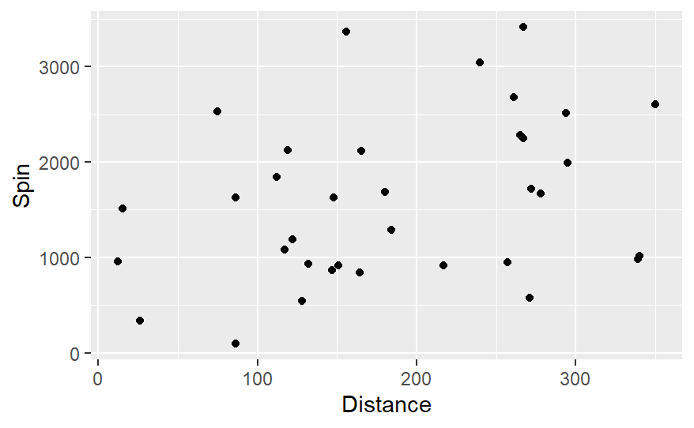

```r
stork_stat %>%
  ggplot(aes(x = Distance, y = Spin))+
  geom_point()
```

The next graph will show exit velo and distance

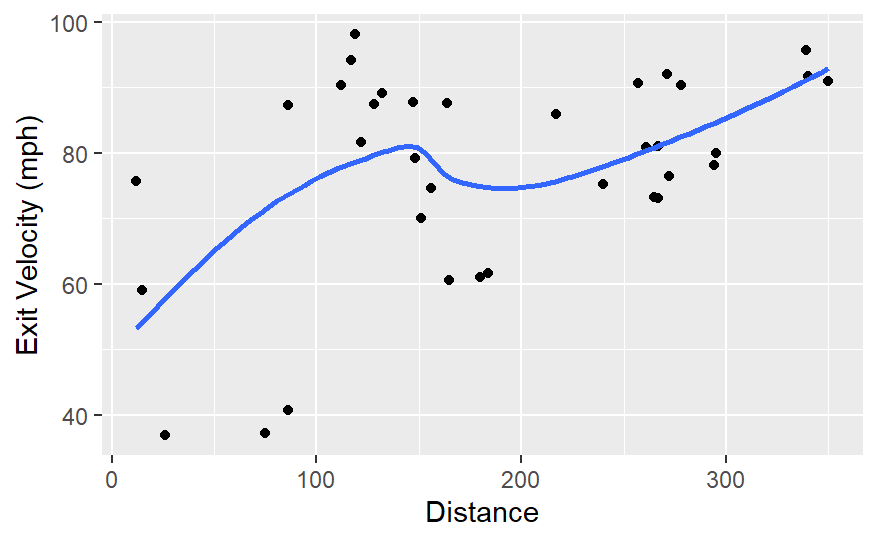

```r
stork_stat %>%
  ggplot(aes(x = Distance, y = Exit.Velo.))+
  geom_point() +
  stat_smooth(se = FALSE) +
  ylab("Exit Velocity (mph)")
```

The last graph we want to make shows distance vs launch angle

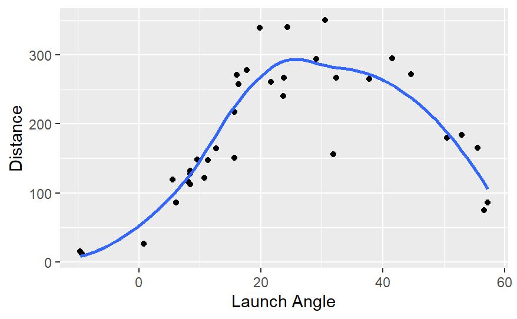

```r
stork_stat %>%
  ggplot(aes(x = L..Angle, y = Distance))+
  geom_point() +
  stat_smooth(se = FALSE) +
  xlab("Launch Angle")
```

Lastly, let’s look at spin rate vs distance

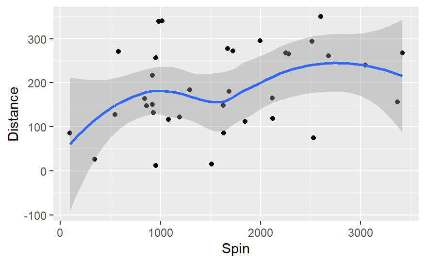

```r
stork_stat %>%
  ggplot(aes(x = Spin, y = Distance))+
  geom_point() +
  stat_smooth()
```